# Dietary intake, Nutritional status, and Health outcomes among Vegan, Vegetarian and Omnivore families: results from the observational study

- Show All Code
- Hide All Code
- View Source

Statistical report - mixed models summary

**Authors and affiliations**

Marina Heniková<sup>1,2</sup>, Anna Ouřadová<sup>1</sup>, Eliška Selinger<sup>1,3</sup>, Filip Tichanek<sup>4</sup>, Petra Polakovičová<sup>4</sup>, Dana Hrnčířová<sup>2</sup>, Pavel Dlouhý<sup>2</sup>, Martin Světnička<sup>5</sup>, Eva El-Lababidi<sup>5</sup>, Jana Potočková<sup>1</sup>, Tilman Kühn<sup>6</sup>, Monika Cahová<sup>4</sup>, Jan Gojda<sup>1</sup>

<sup>1</sup> Department of Internal Medicine, Kralovske Vinohrady University Hospital and Third Faculty of Medicine, Charles University, Prague, Czech Republic.  
<sup>2</sup> Department of Hygiene, Third Faculty of Medicine, Charles University, Prague, Czech Republic.  
<sup>3</sup> National Health Institute, Prague, Czech Republic.  
<sup>4</sup> Institute for Clinical and Experimental Medicine, Prague, Czech Republic.  
<sup>5</sup> Department of Pediatrics, Kralovske Vinohrady University Hospital and Third Faculty of Medicine, Charles University, Prague, Czech Republic.  
<sup>6</sup> Department of Epidemiology, MedUni, Vienna, Austria.

When using this code or data, cite the original publication:

Original [GitHub repository](https://github.com/filip-tichanek/kompas_clinical): https://github.com/filip-tichanek/kompas_clinical

Statistical **reports** can be found on the [reports hub](https://filip-tichanek.github.io/kompas_clinical/).

Data analysis is described in detail in the [statistical methods](https://filip-tichanek.github.io/kompas_clinical/368_G_Methods.html) report.

# 1 Introduction

This project is designed to evaluate and compare clinical outcomes across three distinct dietary strategy groups:

- Vegans
- Vegetarians
- Omnivores

The dataset is structured with data clustered within families, encompassing both adults and children. Children and adults are analyzed separately. The analysis for children is twofold: firstly, all children are considered as a single group with age (log2-transformed) serving as a covariate; secondly, a more detailed examination divides children into two age groups—those younger than 3 years and those 3 years and older.

## 1.1 Main Questions

The study aims to address the following key questions:

Q1. Do clinical outcomes vary significantly across different diet strategies?

Q2. Are there differences in the broader variability of clinical outcomes across diet groups, beyond just the average/median values?

Q3. Beyond diet group, what factors (such sex, age, breastfeeding status in children) are the most important drivers of clinical outcomes? How much are clinical charactersitics clustered within families?

Q4. Could the clinical characteristics effectively discriminate between different diet groups?

## 1.2 Statistical methods

Statistical modelling is described in detail in [this report](https://filip-tichanek.github.io/kompas_clinical/368_G_Methods.html). Briefly, statistical methods used included:

The **Kruskal-Wallis** test and **Mann-Whitney U test** to compare unadjusted medians, **Fisher test** was used to compare unadjusted proportions (Q1).

**Quantile regression** (QR) was used to obtain adjusted differences in medians (Q1), 20th and 80th percentiles of the clinical characteristics (Q2), and to assess the relative importance of other covariates (Q3). **Linear mixed-effects models** (LME) provided information about adjusted differences between diet groups (Q1) and the importance of other variables, including clustering within families (Q3).  
Both QR and LME **were adjusted for confounders including age, sex, breast-feeding status (children), and relevant supplementation**.

**Elastic net logistic regression** was employed to address Q4, offering a predictive perspective on the role of diet in determining clinical profiles.

Separate analyses were conducted for adults and children. For children, the analysis included a joint examination of all children, incorporating log2(age) as a covariate, and subgroup-specific analyses of children *under* and *over* 3 years of age separately.

# 2 Import initiation file

**Open code**

```r
source('368_initiation.R')
```

# 3 All children

## 3.1 Diet effects

### 3.1.1 Unstandardized effects

**Open code**

```r
diet_child_all <- read.xlsx("gitignore/data/diet_child_all_mixeff.xlsx") %>%
  mutate(outcome = clean_outcome_names(outcome)) %>%
  mutate(outcome = case_when(
    outcome == 'FOLAT' ~ 'FOLATE',
    outcome == 'VKFE' ~ 'TIBC',
    outcome == 'Cros' ~ 'CTX',
    outcome == 'log2_Cros' ~ 'log2_CTX',
    outcome == 'VIT_AKTB12' ~ 'HOLOTC',
    outcome == 'log2_VIT_AKTB12' ~ 'log2_HOLOTC',
    TRUE ~ outcome
  ))

diet_child_all2 <- diet_child_all %>%
  mutate(across(.cols = c(VN_OM_diff, VG_OM_diff, VN_VG_diff), ~ round(.x, 2)))


kbl(diet_child_all2, caption =
      "Differences between diet groups across outcomes in all children, based on mixed models") %>%
  kable_styling("striped",full_width = T) %>%
  add_header_above(c(" " = 2, "(A) VN vs OM" = 3,
                     "(B) VG vs OM" = 3, "(C) VN vs VG" =3)) %>%
  column_spec(1, width_min = '1.5in')
```

Differences between diet groups across outcomes in all children, based on mixed models

| outcome | estimand | (A) VN vs OM VN_OM_diff | (A) VN vs OM VN_OM_P | (A) VN vs OM VN_OM_P_adj | (B) VG vs OM VG_OM_diff | (B) VG vs OM VG_OM_P | (B) VG vs OM VG_OM_P_adj | (C) VN vs VG VN_VG_diff | (C) VN vs VG VN_VG_P | (C) VN vs VG VN_VG_P_adj |
| --- | --- | --- | --- | --- | --- | --- | --- | --- | --- | --- |
| MASS_Perc | mean | -9.23 | 0.13688 | 0.41064 | -3.60 | 0.61402 | 0.61402 | -5.63 | 0.37989 | 0.61402 |
| HEIGHT_Perc | mean | -7.97 | 0.23057 | 0.46113 | 0.86 | 0.91140 | 0.91140 | -8.83 | 0.19679 | 0.46113 |
| BMI_PERC | mean | -2.32 | 0.70470 | 0.94034 | -2.79 | 0.69401 | 0.94034 | 0.47 | 0.94034 | 0.94034 |
| M_per_H_PERC | mean | -3.17 | 0.57477 | 0.93313 | -3.66 | 0.57166 | 0.93313 | 0.49 | 0.93313 | 0.93313 |
| GLY | mean | 0.01 | 0.91954 | 0.91954 | 0.05 | 0.64820 | 0.91954 | -0.04 | 0.69971 | 0.91954 |
| TC | mean | -0.32 | 0.03708 | 0.11125 | -0.18 | 0.30836 | 0.40901 | -0.14 | 0.40901 | 0.40901 |
| HDL | mean | -0.01 | 0.88269 | 0.88269 | -0.06 | 0.49973 | 0.88269 | 0.05 | 0.54530 | 0.88269 |
| LDL | mean | -0.25 | 0.02884 | 0.05768 | 0.08 | 0.55454 | 0.55454 | -0.33 | 0.00894 | 0.02683 |
| log2_TG | mean | -0.01 | 0.95663 | 0.95663 | -0.31 | 0.08843 | 0.17687 | 0.30 | 0.07129 | 0.17687 |
| Ca | mean | -0.01 | 0.55571 | 0.77695 | 0.01 | 0.77695 | 0.77695 | -0.02 | 0.38841 | 0.77695 |
| P | mean | -0.03 | 0.46925 | 0.93850 | 0.00 | 0.94091 | 0.94091 | -0.03 | 0.45338 | 0.93850 |
| Mg | mean | 0.03 | 0.03035 | 0.09104 | 0.03 | 0.09092 | 0.18184 | 0.00 | 0.84510 | 0.84510 |
| Se | mean | -0.08 | 0.23932 | 0.69028 | -0.01 | 0.89829 | 0.89829 | -0.07 | 0.34514 | 0.69028 |
| Zn | mean | -0.96 | 0.05859 | 0.17578 | -0.65 | 0.27633 | 0.55265 | -0.31 | 0.58553 | 0.58553 |
| FE | mean | 1.81 | 0.18884 | 0.37768 | -0.77 | 0.62502 | 0.62502 | 2.58 | 0.08744 | 0.26232 |
| TIBC | mean | -4.02 | 0.03236 | 0.09708 | -1.47 | 0.49317 | 0.49317 | -2.54 | 0.21603 | 0.43205 |
| log2_FERR | mean | -0.25 | 0.12955 | 0.38864 | -0.19 | 0.31426 | 0.62851 | -0.06 | 0.74592 | 0.74592 |
| TRF | mean | -0.17 | 0.02428 | 0.07284 | -0.07 | 0.40726 | 0.40726 | -0.10 | 0.23903 | 0.40726 |
| SATTRF | mean | 3.82 | 0.05154 | 0.14774 | -0.03 | 0.98860 | 0.98860 | 3.85 | 0.07387 | 0.14774 |
| log2_TRFINDEX | mean | 0.03 | 0.69509 | 0.69509 | 0.08 | 0.44718 | 0.69509 | -0.04 | 0.65937 | 0.69509 |
| log2_STRF | mean | -0.03 | 0.57242 | 0.83995 | 0.01 | 0.83995 | 0.83995 | -0.04 | 0.46796 | 0.83995 |
| HGB | mean | -0.44 | 0.81017 | 0.81017 | 1.14 | 0.59125 | 0.81017 | -1.58 | 0.43375 | 0.81017 |
| MCV | mean | 2.97 | 0.00015 | 0.00046 | -0.13 | 0.89233 | 0.89233 | 3.10 | 0.00028 | 0.00055 |
| PTH | mean | 0.38 | 0.20390 | 0.44532 | -0.02 | 0.96165 | 0.96165 | 0.39 | 0.22266 | 0.44532 |
| log2_CTX | mean | 0.06 | 0.46383 | 0.71548 | 0.08 | 0.34496 | 0.71548 | -0.03 | 0.71548 | 0.71548 |
| P1NP | mean | 41.88 | 0.28956 | 0.57913 | 63.17 | 0.18199 | 0.54598 | -21.29 | 0.62181 | 0.62181 |
| UI | mean | -69.96 | 0.00126 | 0.00378 | -31.96 | 0.18198 | 0.18198 | -38.00 | 0.08104 | 0.16209 |
| UREA | mean | -0.55 | 0.01043 | 0.03128 | -0.17 | 0.48818 | 0.48818 | -0.38 | 0.10751 | 0.21503 |
| log2_CREA | mean | -0.11 | 0.04170 | 0.12510 | -0.06 | 0.33500 | 0.40037 | -0.05 | 0.40037 | 0.40037 |
| UA | mean | -2.38 | 0.83143 | 0.83143 | -4.94 | 0.70864 | 0.83143 | 2.56 | 0.83104 | 0.83143 |
| log2_HOLOTC | mean | 0.30 | 0.15379 | 0.15379 | -0.31 | 0.14491 | 0.15379 | 0.61 | 0.00026 | 0.00077 |
| log2_HCY | mean | -0.30 | 0.00024 | 0.00073 | -0.11 | 0.26789 | 0.26789 | -0.19 | 0.05267 | 0.10533 |
| log2_MMA | mean | -0.79 | 0.00000 | 0.00000 | -0.26 | 0.14051 | 0.14051 | -0.53 | 0.00104 | 0.00207 |
| log2_VIT_D | mean | 0.28 | 0.00649 | 0.01948 | 0.26 | 0.03281 | 0.06562 | 0.02 | 0.86447 | 0.86447 |
| FOLATE | mean | 4.30 | 0.00001 | 0.00002 | 4.81 | 0.00002 | 0.00004 | -0.51 | 0.61983 | 0.61983 |
| log2_IGF1 | mean | -0.16 | 0.28835 | 0.60499 | 0.01 | 0.95128 | 0.95128 | -0.17 | 0.30250 | 0.60499 |

### 3.1.2 Standardized effects by 1SD

**Open code**

```r
ids <- 11:46
inde <- min(ids)-1
ids <- ids-inde

sds <- vector("double", max(ids))

for(i in seq_along(ids)){
  sds[i] <- ifelse(grepl("log2", diet_child_all[(i), 1]),
                   sd(log2(dat_child_all[,(i+inde)]), na.rm = TRUE),
                   sd(dat_child_all[,(i+inde)], na.rm = TRUE))
}


diet_child_all_Z <- diet_child_all %>%
  mutate(SD = sds) %>%
  mutate(
    VN_OM_diff = VN_OM_diff/SD,
    VG_OM_diff = VG_OM_diff/SD,
    VN_VG_diff = VN_VG_diff/SD) %>%
  select(-c(SD)) %>%
  mutate(across(.cols = c(VG_OM_diff, VN_OM_diff, VN_VG_diff), ~ round(.x, 2)))


kbl(diet_child_all_Z, caption =
      "Standardized differences between diet groups across outcomes in all children, based on mixed models") %>%
  kable_styling("striped",full_width = T) %>%
  add_header_above(c(" " = 2, "(A) VN vs OM" = 3,
                     "(B) VG vs OM" = 3, "(C) VN vs VG" =3)) %>%
  column_spec(1, width_min = '1.5in')
```

Standardized differences between diet groups across outcomes in all children, based on mixed models

| outcome | estimand | (A) VN vs OM VN_OM_diff | (A) VN vs OM VN_OM_P | (A) VN vs OM VN_OM_P_adj | (B) VG vs OM VG_OM_diff | (B) VG vs OM VG_OM_P | (B) VG vs OM VG_OM_P_adj | (C) VN vs VG VN_VG_diff | (C) VN vs VG VN_VG_P | (C) VN vs VG VN_VG_P_adj |
| --- | --- | --- | --- | --- | --- | --- | --- | --- | --- | --- |
| MASS_Perc | mean | -0.32 | 0.13688 | 0.41064 | -0.12 | 0.61402 | 0.61402 | -0.20 | 0.37989 | 0.61402 |
| HEIGHT_Perc | mean | -0.29 | 0.23057 | 0.46113 | 0.03 | 0.91140 | 0.91140 | -0.32 | 0.19679 | 0.46113 |
| BMI_PERC | mean | -0.09 | 0.70470 | 0.94034 | -0.11 | 0.69401 | 0.94034 | 0.02 | 0.94034 | 0.94034 |
| M_per_H_PERC | mean | -0.13 | 0.57477 | 0.93313 | -0.15 | 0.57166 | 0.93313 | 0.02 | 0.93313 | 0.93313 |
| GLY | mean | 0.02 | 0.91954 | 0.91954 | 0.09 | 0.64820 | 0.91954 | -0.07 | 0.69971 | 0.91954 |
| TC | mean | -0.49 | 0.03708 | 0.11125 | -0.28 | 0.30836 | 0.40901 | -0.21 | 0.40901 | 0.40901 |
| HDL | mean | -0.04 | 0.88269 | 0.88269 | -0.19 | 0.49973 | 0.88269 | 0.15 | 0.54530 | 0.88269 |
| LDL | mean | -0.45 | 0.02884 | 0.05768 | 0.14 | 0.55454 | 0.55454 | -0.58 | 0.00894 | 0.02683 |
| log2_TG | mean | -0.01 | 0.95663 | 0.95663 | -0.43 | 0.08843 | 0.17687 | 0.42 | 0.07129 | 0.17687 |
| Ca | mean | -0.13 | 0.55571 | 0.77695 | 0.07 | 0.77695 | 0.77695 | -0.20 | 0.38841 | 0.77695 |
| P | mean | -0.16 | 0.46925 | 0.93850 | 0.02 | 0.94091 | 0.94091 | -0.18 | 0.45338 | 0.93850 |
| Mg | mean | 0.40 | 0.03035 | 0.09104 | 0.36 | 0.09092 | 0.18184 | 0.04 | 0.84510 | 0.84510 |
| Se | mean | -0.28 | 0.23932 | 0.69028 | -0.04 | 0.89829 | 0.89829 | -0.24 | 0.34514 | 0.69028 |
| Zn | mean | -0.40 | 0.05859 | 0.17578 | -0.27 | 0.27633 | 0.55265 | -0.13 | 0.58553 | 0.58553 |
| FE | mean | 0.26 | 0.18884 | 0.37768 | -0.11 | 0.62502 | 0.62502 | 0.37 | 0.08744 | 0.26232 |
| TIBC | mean | -0.44 | 0.03236 | 0.09708 | -0.16 | 0.49317 | 0.49317 | -0.28 | 0.21603 | 0.43205 |
| log2_FERR | mean | -0.28 | 0.12955 | 0.38864 | -0.22 | 0.31426 | 0.62851 | -0.07 | 0.74592 | 0.74592 |
| TRF | mean | -0.47 | 0.02428 | 0.07284 | -0.20 | 0.40726 | 0.40726 | -0.27 | 0.23903 | 0.40726 |
| SATTRF | mean | 0.39 | 0.05154 | 0.14774 | 0.00 | 0.98860 | 0.98860 | 0.39 | 0.07387 | 0.14774 |
| log2_TRFINDEX | mean | 0.06 | 0.69509 | 0.69509 | 0.14 | 0.44718 | 0.69509 | -0.08 | 0.65937 | 0.69509 |
| log2_STRF | mean | -0.11 | 0.57242 | 0.83995 | 0.04 | 0.83995 | 0.83995 | -0.15 | 0.46796 | 0.83995 |
| HGB | mean | -0.05 | 0.81017 | 0.81017 | 0.12 | 0.59125 | 0.81017 | -0.17 | 0.43375 | 0.81017 |
| MCV | mean | 0.78 | 0.00015 | 0.00046 | -0.03 | 0.89233 | 0.89233 | 0.81 | 0.00028 | 0.00055 |
| PTH | mean | 0.30 | 0.20390 | 0.44532 | -0.01 | 0.96165 | 0.96165 | 0.31 | 0.22266 | 0.44532 |
| log2_CTX | mean | 0.15 | 0.46383 | 0.71548 | 0.24 | 0.34496 | 0.71548 | -0.08 | 0.71548 | 0.71548 |
| P1NP | mean | 0.14 | 0.28956 | 0.57913 | 0.21 | 0.18199 | 0.54598 | -0.07 | 0.62181 | 0.62181 |
| UI | mean | -0.49 | 0.00126 | 0.00378 | -0.22 | 0.18198 | 0.18198 | -0.27 | 0.08104 | 0.16209 |
| UREA | mean | -0.44 | 0.01043 | 0.03128 | -0.14 | 0.48818 | 0.48818 | -0.30 | 0.10751 | 0.21503 |
| log2_CREA | mean | -0.27 | 0.04170 | 0.12510 | -0.15 | 0.33500 | 0.40037 | -0.12 | 0.40037 | 0.40037 |
| UA | mean | -0.05 | 0.83143 | 0.83143 | -0.10 | 0.70864 | 0.83143 | 0.05 | 0.83104 | 0.83143 |
| log2_HOLOTC | mean | 0.37 | 0.15379 | 0.15379 | -0.38 | 0.14491 | 0.15379 | 0.75 | 0.00026 | 0.00077 |
| log2_HCY | mean | -0.66 | 0.00024 | 0.00073 | -0.24 | 0.26789 | 0.26789 | -0.42 | 0.05267 | 0.10533 |
| log2_MMA | mean | -0.87 | 0.00000 | 0.00000 | -0.29 | 0.14051 | 0.14051 | -0.58 | 0.00104 | 0.00207 |
| log2_VIT_D | mean | 0.61 | 0.00649 | 0.01948 | 0.57 | 0.03281 | 0.06562 | 0.04 | 0.86447 | 0.86447 |
| FOLATE | mean | 0.92 | 0.00001 | 0.00002 | 1.03 | 0.00002 | 0.00004 | -0.11 | 0.61983 | 0.61983 |
| log2_IGF1 | mean | -0.19 | 0.28835 | 0.60499 | 0.01 | 0.95128 | 0.95128 | -0.20 | 0.30250 | 0.60499 |

## 3.2 Vulcano plots

### 3.2.1 VN vs OM

**Open code**

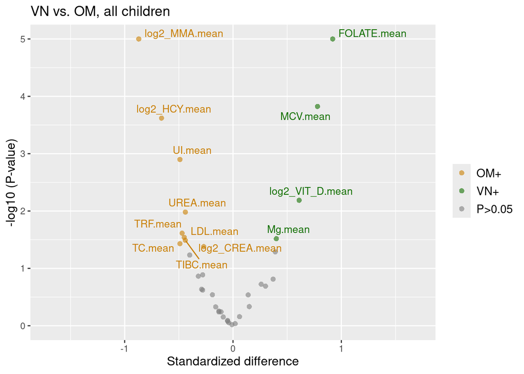

Figure 19. Vulcano plot showing standardized differences between VN and OM across clinical outcomes in all children, based on mixed-effects models

```r
color_map <- c('OM+' = '#C97F00',
               'VN+' = '#137000',
               'VG+' = '#103CC9',
               'P>0.05' = 'grey50')

plotac <- 'fig19'

path = paste0('gitignore/figures/',plotac, '.rds')

if(file.exists(path) == FALSE){
  assign(plotac, diet_child_all_Z %>%
           filter(estimand != 'log(OR)') %>%
           mutate(int = interaction(outcome, estimand)) %>%

           mutate(
             pv_adj = VN_OM_P_adj,
             pv_raw = VN_OM_P,
             b_coe = VN_OM_diff) %>%

           mutate(pv_raw = if_else(pv_raw < 1e-5, 1e-5, pv_raw)) %>%

           mutate(
             m_ylab = -log10(pv_raw),
             m_xlab = b_coe,
             rescat = if_else(
               pv_raw >= 0.05,
               'P>0.05',
               if_else(
                 b_coe > 0,
                 'VN+',
                 'OM+'))) %>%

           mutate(
             rescat = factor(rescat,
                             levels = c('OM+', 'VN+', 'P>0.05')),
             meta_labels = if_else(pv_raw < 0.05, int, '')) %>%

           ggplot(aes(x = b_coe,
                      y = m_ylab,
                      color = rescat,
                      alpha = rescat,
                      label = meta_labels)) +

           geom_point(size = 2, shape = 16, alpha = 0.6) +

           geom_text_repel(aes(
             x = m_xlab,
             y = m_ylab),
             show.legend = FALSE,
             alpha = 1,
             box.padding = 0.3,
             size = 3.5,
             seed = 17) +

           labs(x = 'Standardized difference', y = '-log10 (P-value)') +
           scale_color_manual(values=color_map, name = '') +
           ggtitle('VN vs. OM, all children') +
           theme(legend.text = element_text(size = 11),
                 axis.title = element_text(size = 12))+
           coord_cartesian(ylim = c(0, 5),
                           xlim = c(-1.7, 1.7))
         )

  saveRDS(get(plotac), file = path)
  get(plotac)

} else {assign(plotac, readRDS(path))
    get(plotac)}
```

### 3.2.2 VG vs OM

**Open code**

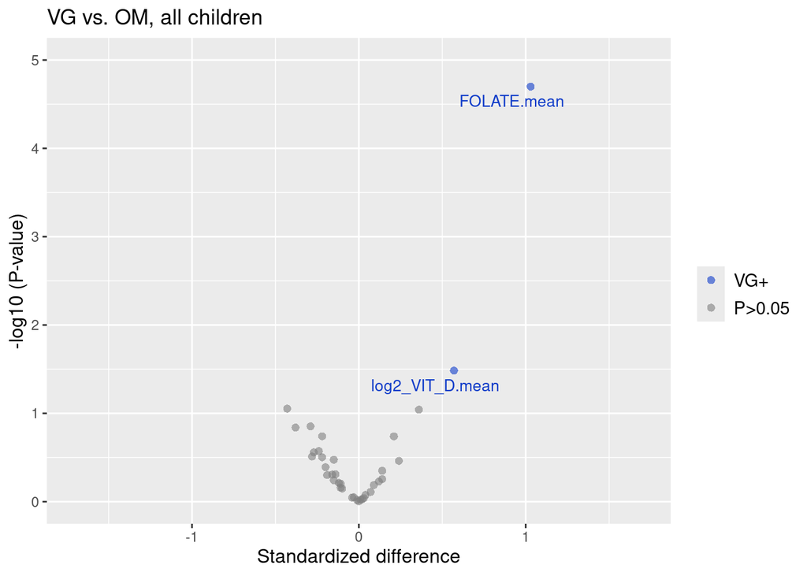

Figure 20. Vulcano plot showing standardized differences between VG and OM across clinical outcomes in all children, based on mixed-effects models

```r
plotac <- 'fig20'

path = paste0('gitignore/figures/',plotac, '.rds')

if(file.exists(path) == FALSE){
  assign(plotac, diet_child_all_Z %>%
           filter(estimand != 'log(OR)') %>%
           mutate(int = interaction(outcome, estimand)) %>%
           mutate(VG_OM_P = if_else(VG_OM_P < 1e-5, 1e-5, VG_OM_P)) %>%
           mutate(
             pv_adj = VG_OM_P_adj,
             pv_raw = VG_OM_P,
             b_coe = VG_OM_diff) %>%

           mutate(pv_raw = if_else(pv_raw < 1e-5, 1e-5, pv_raw)) %>%

           mutate(
             m_ylab = -log10(pv_raw),
             m_xlab = b_coe,
             rescat = if_else(
               pv_raw >= 0.05,
               'P>0.05',
               if_else(
                 b_coe > 0,
                 'VG+',
                 'OM+'))) %>%

           mutate(
             rescat = factor(rescat,
                             levels = c('OM+', 'VG+', 'P>0.05')),
             meta_labels = if_else(pv_raw < 0.05, int, '')) %>%

           ggplot(aes(x = b_coe,
                      y = m_ylab,
                      color = rescat,
                      alpha = rescat,
                      label = meta_labels)) +

           geom_point(size = 2, shape = 16, alpha = 0.6) +
           geom_text_repel(aes(
             x = m_xlab,
             y = m_ylab),
             show.legend = FALSE,
             alpha=1,
             box.padding = 0.3,
             size = 3.5,
             seed = 17) +

           labs(x = 'Standardized difference', y = '-log10 (P-value)') +
           scale_color_manual(values = color_map, name = '') +
           ggtitle('VG vs. OM, all children') +
           theme(legend.text = element_text(size = 11),
                 axis.title = element_text(size = 12))+
           coord_cartesian(ylim = c(0, 5),
                           xlim = c(-1.7, 1.7))
         )

  saveRDS(get(plotac), file = path)
  get(plotac)

} else {assign(plotac, readRDS(path))
    get(plotac)}
```

### 3.2.3 VN vs VG

**Open code**

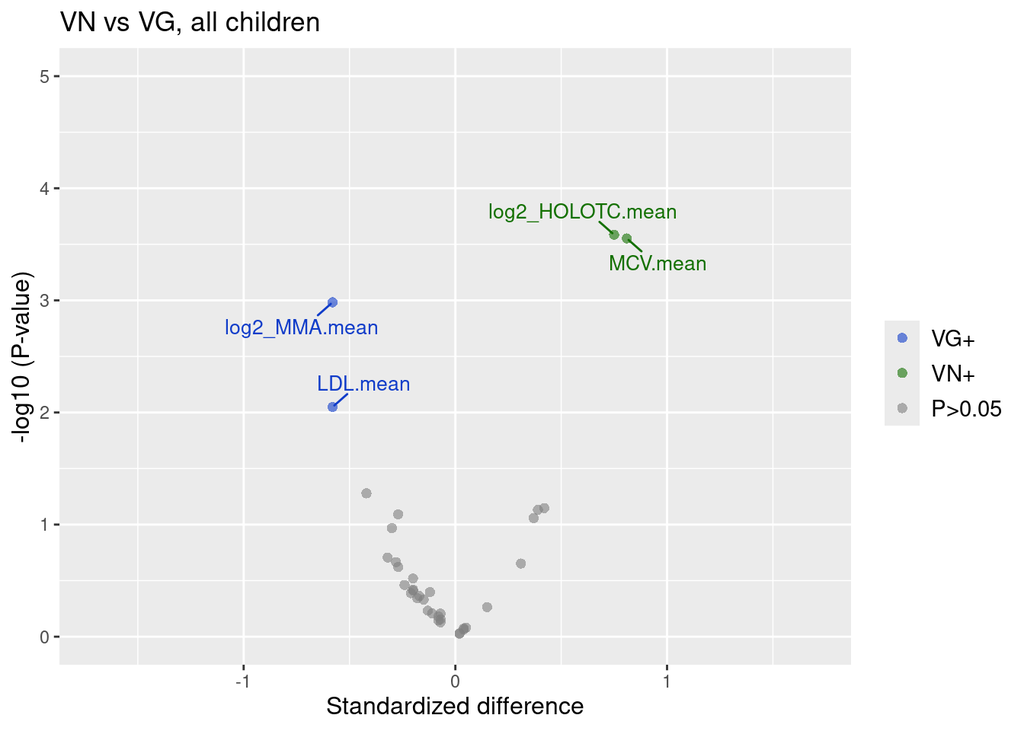

Figure 21. Vulcano plot showing standardized differences between VG and VN across clinical outcomes in all children, based on mixed-effects models

```r
plotac <- 'fig21'

path = paste0('gitignore/figures/', plotac, '.rds')

if(file.exists(path) == FALSE){
  assign(plotac, diet_child_all_Z %>%
             filter(estimand != 'log(OR)') %>%
           mutate(int = interaction(outcome, estimand)) %>%

           mutate(
             pv_adj = VN_VG_P_adj,
             pv_raw = VN_VG_P,
             b_coe = VN_VG_diff) %>%

           mutate(pv_raw = if_else(pv_raw < 1e-5, 1e-5, pv_raw)) %>%

           mutate(
             m_ylab = -log10(pv_raw),
             m_xlab = b_coe,
             rescat = if_else(
               pv_raw >= 0.05,
               'P>0.05',
               if_else(
                 b_coe > 0,
                 'VN+',
                 'VG+'))) %>%

           mutate(
             rescat = factor(rescat,
                             levels=c('VG+',
                                      'VN+',
                                      'P>0.05')),
             meta_labels = if_else(pv_raw < 0.05, int, '')) %>%

           ggplot(aes(x = b_coe,
                      y = m_ylab,
                      color = rescat,
                      alpha = rescat,
                      label = meta_labels)) +

           geom_point(size = 2, shape = 16, alpha = 0.6) +

           geom_text_repel(aes(
             x = m_xlab,
             y = m_ylab),
             show.legend = FALSE,
             alpha = 1,
             box.padding = 0.5,
             size = 3.5,
             seed = 16) +

           labs(x = 'Standardized difference',
                y = '-log10 (P-value)') +

           scale_color_manual(values = color_map, name = '') +
           ggtitle('VN vs VG, all children') +

           theme(legend.text = element_text(size = 11),
                 axis.title = element_text(size = 12))+
           coord_cartesian(ylim = c(0, 5),
                           xlim = c(-1.7, 1.7))
         )

  saveRDS(get(plotac), file = path)
  get(plotac)

} else {assign(plotac, readRDS(path))
    get(plotac)}
```

## 3.3 Covariates importance

### 3.3.1 Table

**Open code**

```r
AIC_child_all <- read.xlsx("gitignore/data/AIC_child_all_mixeff.xlsx") %>%
  mutate(across(where(is.numeric), ~round(., 1)),
         outcome = clean_outcome_names(outcome)) %>%
  rename(
    SEX = aSEX,
    BREASTFEED = Breast_Feed,
    `OTHER COV` = other_cov,
    FAMILY = family,
    DIET = diet,
    AGE = log2_age
  ) %>%
  mutate(outcome = case_when(
    outcome == 'FOLAT' ~ 'FOLATE',
    outcome == 'VKFE' ~ 'TIBC',
    outcome == 'Cros' ~ 'CTX',
    outcome == 'log2_Cros' ~ 'log2_CTX',
    outcome == 'VIT_AKTB12' ~ 'HOLOTC',
    outcome == 'log2_VIT_AKTB12' ~ 'log2_HOLOTC',
    TRUE ~ outcome
  ))

kbl(AIC_child_all, caption =
      "Decrease of The Akaike information criterion (AIC) after addition of given outcome to mixed-effects model, all children. The change of AIC indicate out-of-sample predictive accuracy of the models and was bounded to -30 (large importance of a covariate, blue) and 0 (no to negliable importance, red).") %>%
  kable_styling("striped",full_width = T) %>%
  column_spec(1, width_min = '1.5in')
```

Decrease of The Akaike information criterion (AIC) after addition of given outcome to mixed-effects model, all children. The change of AIC indicate out-of-sample predictive accuracy of the models and was bounded to -30 (large importance of a covariate, blue) and 0 (no to negliable importance, red).

| outcome | estimand | AGE | SEX | BREASTFEED | OTHER COV | DIET | FAMILY |
| --- | --- | --- | --- | --- | --- | --- | --- |
| MASS_Perc | mean | NA | 1.9 | 2.9 | -25.4 | 1.8 | -4.8 |
| HEIGHT_Perc | mean | NA | 2.3 | 5.1 | -18.5 | 1.2 | -9.2 |
| BMI_PERC | mean | NA | 0.8 | 4.4 | -9.6 | 4.2 | -2.6 |
| M_per_H_PERC | mean | NA | 1.5 | 4.6 | -9.4 | 4.1 | -1.1 |
| GLY | mean | 2.3 | 2.0 | 5.7 | NA | 4.4 | 1.7 |
| TC | mean | 1.8 | 2.3 | 3.2 | NA | -0.6 | -1.1 |
| HDL | mean | -5.9 | -1.4 | 3.5 | NA | 3.8 | -6.7 |
| LDL | mean | 2.3 | 1.9 | 2.6 | NA | -3.1 | -1.3 |
| log2_TG | mean | -2.4 | -0.8 | 3.6 | NA | 0.7 | -5.4 |
| Ca | mean | -23.2 | 0.8 | 5.2 | 1.8 | 4.0 | -4.3 |
| P | mean | -33.7 | 2.3 | 3.3 | NA | 3.7 | -5.0 |
| Mg | mean | -0.4 | 1.5 | 0.2 | 1.5 | 0.7 | 0.1 |
| Se | mean | 2.3 | 2.3 | 3.2 | -3.2 | 3.3 | -4.8 |
| Zn | mean | 0.9 | 2.3 | 6.6 | 2.3 | 2.1 | -0.9 |
| FE | mean | -6.8 | 2.0 | 6.3 | 2.3 | 2.6 | -1.8 |
| TIBC | mean | 0.4 | 2.1 | -2.6 | -2.5 | 0.5 | -4.2 |
| log2_FERR | mean | -13.3 | 1.7 | -12.1 | -1.3 | 2.5 | -1.9 |
| TRF | mean | 0.8 | 1.8 | -3.0 | -2.9 | 0.0 | -3.4 |
| SATTRF | mean | -7.5 | 1.9 | 5.0 | 1.7 | 1.3 | -1.1 |
| log2_TRFINDEX | mean | -19.8 | 1.2 | -12.1 | -2.5 | 4.2 | -0.2 |
| log2_STRF | mean | -18.3 | 1.8 | -7.7 | -3.4 | 3.8 | -0.3 |
| HGB | mean | -14.0 | 1.5 | 4.7 | NA | 4.2 | -4.1 |
| MCV | mean | -20.5 | 0.8 | -0.6 | NA | -16.7 | -4.8 |
| PTH | mean | -0.6 | 1.6 | 2.8 | NA | 2.5 | -8.3 |
| log2_CTX | mean | 1.8 | 2.0 | 1.9 | 3.0 | 4.1 | 1.6 |
| P1NP | mean | -77.2 | -1.4 | 0.7 | 4.1 | 3.0 | 0.4 |
| UI | mean | 2.0 | 1.5 | 4.6 | NA | 4.3 | 2.0 |
| UREA | mean | -10.4 | -0.3 | -0.8 | NA | -4.3 | -6.5 |
| log2_CREA | mean | -84.9 | 1.0 | 2.1 | NA | 1.4 | 0.8 |
| UA | mean | 2.2 | 2.1 | 3.3 | NA | 4.0 | -6.1 |
| log2_HOLOTC | mean | -6.0 | 1.7 | 1.4 | -7.7 | -5.5 | -13.1 |
| log2_HCY | mean | 2.2 | -6.2 | -17.6 | NA | -8.0 | -6.2 |
| log2_MMA | mean | 0.6 | 1.0 | -22.7 | NA | -15.2 | -7.0 |
| log2_VIT_D | mean | -1.9 | 2.3 | 4.7 | -0.1 | -1.6 | -19.7 |
| FOLATE | mean | -11.4 | 2.3 | 5.4 | 1.6 | -15.7 | -6.0 |
| log2_IGF1 | mean | -60.6 | 2.3 | 0.7 | NA | 2.9 | -6.9 |

### 3.3.2 Heatmap

**Open code**

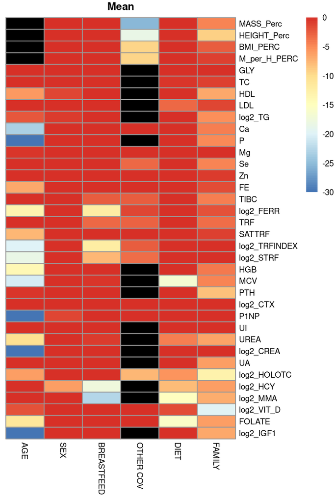

Figure 22. Heatmap showing the extend of decrase of the Akaike information criterion (AIC) after addition of given outcome to mixed effects model, all children. The change of AIC indicate out-of-sample predictive accuracy of the models and was bounded to -30 (large importance of a covariate, blue) and 0 (no to negliable importance, red).

```r
heat_map(AIC_child_all, mixef = TRUE)
```

# 4 Young children

## 4.1 Diet effects

### 4.1.1 Unstandardized effects

**Open code**

```r
diet_child_young <- read.xlsx("gitignore/data/diet_child_young_mixeff.xlsx") %>%
  mutate(outcome = clean_outcome_names(outcome)) %>%
  mutate(outcome = case_when(
    outcome == 'FOLAT' ~ 'FOLATE',
    outcome == 'VKFE' ~ 'TIBC',
    outcome == 'Cros' ~ 'CTX',
    outcome == 'log2_Cros' ~ 'log2_CTX',
    outcome == 'VIT_AKTB12' ~ 'HOLOTC',
    outcome == 'log2_VIT_AKTB12' ~ 'log2_HOLOTC',
    TRUE ~ outcome
  ))

diet_child_young2 <- diet_child_young %>%
  mutate(across(.cols = c(VN_OM_diff, VG_OM_diff, VN_VG_diff), ~ round(.x, 2)))

kbl(diet_child_young2, caption =
      "Differences between diet groups across outcomes in children < 3 years of age, based on linear models") %>%
  kable_styling("striped",full_width = T) %>%
  add_header_above(c(" " = 2, "(A) VN vs OM" = 3,
                     "(B) VG vs OM" = 3, "(C) VN vs VG" =3)) %>%
  column_spec(1, width_min = '1.5in')
```

| outcome | estimand | (A) VN vs OM VN_OM_diff | (A) VN vs OM VN_OM_P | (A) VN vs OM VN_OM_P_adj | (B) VG vs OM VG_OM_diff | (B) VG vs OM VG_OM_P | (B) VG vs OM VG_OM_P_adj | (C) VN vs VG VN_VG_diff | (C) VN vs VG VN_VG_P | (C) VN vs VG VN_VG_P_adj |
| --- | --- | --- | --- | --- | --- | --- | --- | --- | --- | --- |
| MASS_Perc | mean | -8.89 | 0.22415 | 0.67244 | -3.48 | 0.71205 | 0.71205 | -5.41 | 0.51769 | 0.71205 |
| HEIGHT_Perc | mean | -10.80 | 0.12128 | 0.36383 | -5.40 | 0.54790 | 0.54790 | -5.40 | 0.49813 | 0.54790 |
| BMI_PERC | mean | -1.85 | 0.80161 | 0.81694 | 2.19 | 0.81694 | 0.81694 | -4.04 | 0.63055 | 0.81694 |
| M_per_H_PERC | mean | -3.25 | 0.65184 | 0.84022 | 1.88 | 0.84022 | 0.84022 | -5.13 | 0.53384 | 0.84022 |
| GLY | mean | -0.02 | 0.86650 | 0.86650 | 0.09 | 0.53307 | 0.86650 | -0.11 | 0.41292 | 0.86650 |
| TC | mean | -0.12 | 0.56807 | 0.79324 | 0.07 | 0.79324 | 0.79324 | -0.20 | 0.45158 | 0.79324 |
| HDL | mean | 0.05 | 0.55879 | 0.94085 | -0.01 | 0.94085 | 0.94085 | 0.06 | 0.57646 | 0.94085 |
| LDL | mean | -0.14 | 0.46176 | 0.46176 | 0.30 | 0.24524 | 0.46176 | -0.45 | 0.06129 | 0.18386 |
| log2_TG | mean | -0.02 | 0.93780 | 0.93780 | -0.46 | 0.08690 | 0.17381 | 0.45 | 0.07061 | 0.17381 |
| Ca | mean | -0.02 | 0.53750 | 0.99409 | 0.00 | 0.99409 | 0.99409 | -0.02 | 0.61388 | 0.99409 |
| P | mean | 0.00 | 0.93997 | 0.93997 | 0.07 | 0.19897 | 0.39795 | -0.07 | 0.17804 | 0.39795 |
| Mg | mean | 0.02 | 0.35405 | 0.72449 | 0.02 | 0.36224 | 0.72449 | -0.01 | 0.80600 | 0.80600 |
| Se | mean | -0.05 | 0.47638 | 0.78709 | 0.03 | 0.78709 | 0.78709 | -0.08 | 0.39736 | 0.78709 |
| Zn | mean | -1.14 | 0.03172 | 0.09515 | -0.87 | 0.23307 | 0.46614 | -0.27 | 0.69041 | 0.69041 |
| FE | mean | 1.51 | 0.36585 | 0.54180 | -1.38 | 0.54180 | 0.54180 | 2.89 | 0.16108 | 0.48323 |
| TIBC | mean | -4.22 | 0.08266 | 0.24798 | -2.75 | 0.39986 | 0.62230 | -1.47 | 0.62230 | 0.62230 |
| log2_FERR | mean | -0.10 | 0.67051 | 0.67051 | -0.56 | 0.09374 | 0.27115 | 0.45 | 0.13557 | 0.27115 |
| TRF | mean | -0.18 | 0.06461 | 0.19382 | -0.10 | 0.42990 | 0.52738 | -0.07 | 0.52738 | 0.52738 |
| SATTRF | mean | 3.00 | 0.20429 | 0.40859 | -1.75 | 0.58461 | 0.58461 | 4.74 | 0.10357 | 0.31071 |
| log2_TRFINDEX | mean | -0.07 | 0.58899 | 0.58899 | 0.11 | 0.56358 | 0.58899 | -0.18 | 0.28423 | 0.58899 |
| log2_STRF | mean | -0.09 | 0.27243 | 0.81729 | -0.08 | 0.44585 | 0.89171 | -0.01 | 0.95729 | 0.95729 |
| HGB | mean | 1.86 | 0.43830 | 0.54334 | -1.99 | 0.54334 | 0.54334 | 3.85 | 0.19137 | 0.54334 |
| MCV | mean | 3.50 | 0.00064 | 0.00192 | 1.60 | 0.25321 | 0.25321 | 1.90 | 0.13041 | 0.25321 |
| PTH | mean | 0.42 | 0.27977 | 0.69568 | -0.04 | 0.93672 | 0.93672 | 0.46 | 0.34784 | 0.69568 |
| log2_CTX | mean | 0.06 | 0.45701 | 0.71634 | 0.10 | 0.39117 | 0.71634 | -0.04 | 0.71634 | 0.71634 |
| P1NP | mean | 35.27 | 0.48673 | 0.49072 | 79.95 | 0.26321 | 0.49072 | -44.68 | 0.49072 | 0.49072 |
| UI | mean | -60.52 | 0.05438 | 0.10877 | 9.46 | 0.81096 | 0.81096 | -69.98 | 0.02559 | 0.07677 |
| UREA | mean | -0.65 | 0.03049 | 0.09148 | -0.70 | 0.08522 | 0.17044 | 0.05 | 0.89548 | 0.89548 |
| log2_CREA | mean | -0.12 | 0.09190 | 0.27571 | -0.06 | 0.54859 | 0.54859 | -0.06 | 0.47640 | 0.54859 |
| UA | mean | -11.49 | 0.44838 | 0.88147 | -3.05 | 0.88147 | 0.88147 | -8.44 | 0.65082 | 0.88147 |
| log2_HOLOTC | mean | 0.41 | 0.13904 | 0.27553 | -0.31 | 0.27553 | 0.27553 | 0.72 | 0.00702 | 0.02107 |
| log2_HCY | mean | -0.34 | 0.00185 | 0.00556 | 0.09 | 0.59863 | 0.59863 | -0.43 | 0.00471 | 0.00941 |
| log2_MMA | mean | -1.02 | 0.00000 | 0.00000 | -0.43 | 0.09026 | 0.09026 | -0.58 | 0.00909 | 0.01817 |
| log2_VIT_D | mean | 0.29 | 0.01194 | 0.03583 | 0.27 | 0.09082 | 0.18165 | 0.03 | 0.85886 | 0.85886 |
| FOLATE | mean | 3.98 | 0.00077 | 0.00231 | 4.74 | 0.00252 | 0.00505 | -0.77 | 0.59637 | 0.59637 |
| log2_IGF1 | mean | -0.11 | 0.52748 | 0.98144 | -0.01 | 0.98144 | 0.98144 | -0.10 | 0.65050 | 0.98144 |

### 4.1.2 Standardized effects by 1SD

**Open code**

```r
ids <- 11:46
inde <- min(ids)-1
ids <- ids-inde

sds <- vector("double", max(ids))
meds <- diet_child_young

for(i in seq_along(ids)){
  sds[i] <- ifelse(grepl("log2",meds[(i), 1]),
                   sd(log2(dat_child_young[,(i+inde)]), na.rm=TRUE),
                   sd(dat_child_young[,(i+inde)], na.rm=TRUE))
}


diet_child_young_Z <- diet_child_young %>%
  mutate(SD = sds) %>%
  mutate(VN_OM_diff = VN_OM_diff/SD,
         VG_OM_diff = VG_OM_diff/SD,
         VN_VG_diff = VN_VG_diff/SD) %>%
  select(-SD) %>%
  mutate(across(.cols = c(VN_OM_diff, VG_OM_diff, VN_VG_diff), ~ round(.x, 2)))


kbl(diet_child_young_Z, caption =
      "Standardized differences between diet groups across outcomes in children < 3 years of age, based on linear models") %>%
  kable_styling("striped",full_width = T) %>%
  add_header_above(c(" " = 2, "(A) VN vs OM" = 3,
                     "(B) VG vs OM" = 3, "(C) VN vs VG" =3)) %>%
  column_spec(1, width_min = '1.5in')
```

| outcome | estimand | (A) VN vs OM VN_OM_diff | (A) VN vs OM VN_OM_P | (A) VN vs OM VN_OM_P_adj | (B) VG vs OM VG_OM_diff | (B) VG vs OM VG_OM_P | (B) VG vs OM VG_OM_P_adj | (C) VN vs VG VN_VG_diff | (C) VN vs VG VN_VG_P | (C) VN vs VG VN_VG_P_adj |
| --- | --- | --- | --- | --- | --- | --- | --- | --- | --- | --- |
| MASS_Perc | mean | -0.30 | 0.22415 | 0.67244 | -0.12 | 0.71205 | 0.71205 | -0.18 | 0.51769 | 0.71205 |
| HEIGHT_Perc | mean | -0.39 | 0.12128 | 0.36383 | -0.20 | 0.54790 | 0.54790 | -0.20 | 0.49813 | 0.54790 |
| BMI_PERC | mean | -0.07 | 0.80161 | 0.81694 | 0.08 | 0.81694 | 0.81694 | -0.15 | 0.63055 | 0.81694 |
| M_per_H_PERC | mean | -0.13 | 0.65184 | 0.84022 | 0.07 | 0.84022 | 0.84022 | -0.20 | 0.53384 | 0.84022 |
| GLY | mean | -0.04 | 0.86650 | 0.86650 | 0.20 | 0.53307 | 0.86650 | -0.23 | 0.41292 | 0.86650 |
| TC | mean | -0.18 | 0.56807 | 0.79324 | 0.11 | 0.79324 | 0.79324 | -0.28 | 0.45158 | 0.79324 |
| HDL | mean | 0.16 | 0.55879 | 0.94085 | -0.03 | 0.94085 | 0.94085 | 0.18 | 0.57646 | 0.94085 |
| LDL | mean | -0.22 | 0.46176 | 0.46176 | 0.47 | 0.24524 | 0.46176 | -0.69 | 0.06129 | 0.18386 |
| log2_TG | mean | -0.02 | 0.93780 | 0.93780 | -0.62 | 0.08690 | 0.17381 | 0.60 | 0.07061 | 0.17381 |
| Ca | mean | -0.16 | 0.53750 | 0.99409 | 0.00 | 0.99409 | 0.99409 | -0.16 | 0.61388 | 0.99409 |
| P | mean | 0.02 | 0.93997 | 0.93997 | 0.47 | 0.19897 | 0.39795 | -0.45 | 0.17804 | 0.39795 |
| Mg | mean | 0.23 | 0.35405 | 0.72449 | 0.30 | 0.36224 | 0.72449 | -0.07 | 0.80600 | 0.80600 |
| Se | mean | -0.21 | 0.47638 | 0.78709 | 0.11 | 0.78709 | 0.78709 | -0.32 | 0.39736 | 0.78709 |
| Zn | mean | -0.54 | 0.03172 | 0.09515 | -0.41 | 0.23307 | 0.46614 | -0.13 | 0.69041 | 0.69041 |
| FE | mean | 0.26 | 0.36585 | 0.54180 | -0.23 | 0.54180 | 0.54180 | 0.49 | 0.16108 | 0.48323 |
| TIBC | mean | -0.49 | 0.08266 | 0.24798 | -0.32 | 0.39986 | 0.62230 | -0.17 | 0.62230 | 0.62230 |
| log2_FERR | mean | -0.10 | 0.67051 | 0.67051 | -0.56 | 0.09374 | 0.27115 | 0.45 | 0.13557 | 0.27115 |
| TRF | mean | -0.51 | 0.06461 | 0.19382 | -0.29 | 0.42990 | 0.52738 | -0.22 | 0.52738 | 0.52738 |
| SATTRF | mean | 0.35 | 0.20429 | 0.40859 | -0.20 | 0.58461 | 0.58461 | 0.55 | 0.10357 | 0.31071 |
| log2_TRFINDEX | mean | -0.12 | 0.58899 | 0.58899 | 0.18 | 0.56358 | 0.58899 | -0.30 | 0.28423 | 0.58899 |
| log2_STRF | mean | -0.30 | 0.27243 | 0.81729 | -0.28 | 0.44585 | 0.89171 | -0.02 | 0.95729 | 0.95729 |
| HGB | mean | 0.20 | 0.43830 | 0.54334 | -0.22 | 0.54334 | 0.54334 | 0.42 | 0.19137 | 0.54334 |
| MCV | mean | 0.89 | 0.00064 | 0.00192 | 0.41 | 0.25321 | 0.25321 | 0.48 | 0.13041 | 0.25321 |
| PTH | mean | 0.28 | 0.27977 | 0.69568 | -0.03 | 0.93672 | 0.93672 | 0.31 | 0.34784 | 0.69568 |
| log2_CTX | mean | 0.20 | 0.45701 | 0.71634 | 0.32 | 0.39117 | 0.71634 | -0.12 | 0.71634 | 0.71634 |
| P1NP | mean | 0.12 | 0.48673 | 0.49072 | 0.28 | 0.26321 | 0.49072 | -0.16 | 0.49072 | 0.49072 |
| UI | mean | -0.42 | 0.05438 | 0.10877 | 0.06 | 0.81096 | 0.81096 | -0.48 | 0.02559 | 0.07677 |
| UREA | mean | -0.50 | 0.03049 | 0.09148 | -0.54 | 0.08522 | 0.17044 | 0.04 | 0.89548 | 0.89548 |
| log2_CREA | mean | -0.50 | 0.09190 | 0.27571 | -0.24 | 0.54859 | 0.54859 | -0.26 | 0.47640 | 0.54859 |
| UA | mean | -0.21 | 0.44838 | 0.88147 | -0.06 | 0.88147 | 0.88147 | -0.16 | 0.65082 | 0.88147 |
| log2_HOLOTC | mean | 0.45 | 0.13904 | 0.27553 | -0.34 | 0.27553 | 0.27553 | 0.79 | 0.00702 | 0.02107 |
| log2_HCY | mean | -0.65 | 0.00185 | 0.00556 | 0.16 | 0.59863 | 0.59863 | -0.81 | 0.00471 | 0.00941 |
| log2_MMA | mean | -0.90 | 0.00000 | 0.00000 | -0.38 | 0.09026 | 0.09026 | -0.52 | 0.00909 | 0.01817 |
| log2_VIT_D | mean | 0.66 | 0.01194 | 0.03583 | 0.61 | 0.09082 | 0.18165 | 0.06 | 0.85886 | 0.85886 |
| FOLATE | mean | 0.90 | 0.00077 | 0.00231 | 1.08 | 0.00252 | 0.00505 | -0.17 | 0.59637 | 0.59637 |
| log2_IGF1 | mean | -0.16 | 0.52748 | 0.98144 | -0.01 | 0.98144 | 0.98144 | -0.15 | 0.65050 | 0.98144 |

## 4.2 Vulcano plots

### 4.2.1 VN vs. OM

**Open code**

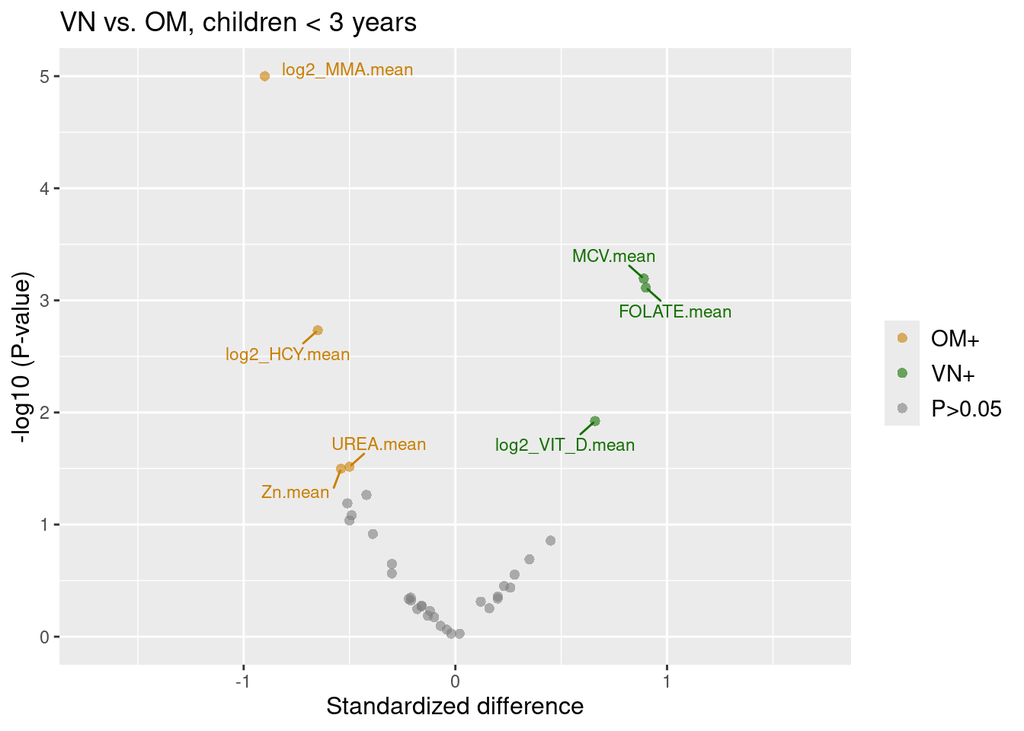

```r
plotac <- 'fig23'

path = paste0('gitignore/figures/',plotac, '.rds')

if(file.exists(path) == FALSE){
  assign(plotac, diet_child_young_Z %>%
           filter(estimand != 'log(OR)') %>%
           mutate(int = interaction(outcome, estimand)) %>%

           mutate(
             pv_adj = VN_OM_P_adj,
             pv_raw = VN_OM_P,
             b_coe = VN_OM_diff) %>%

           mutate(pv_raw = if_else(pv_raw < 1e-5, 1e-5, pv_raw)) %>%

           mutate(
             m_ylab = -log10(pv_raw),
             m_xlab = b_coe,
             rescat = if_else(
               pv_raw >= 0.05,
               'P>0.05',
               if_else(
                 b_coe > 0,
                 'VN+',
                 'OM+'))) %>%

           mutate(
             rescat = factor(rescat,
                             levels = c('OM+', 'VN+', 'P>0.05')),
             meta_labels = if_else(pv_raw < 0.05, int, '')) %>%

           ggplot(aes(x = b_coe,
                      y = m_ylab,
                      color = rescat,
                      alpha = rescat,
                      label = meta_labels)) +

           geom_point(size = 2, shape = 16, alpha = 0.6) +

           geom_text_repel(aes(
             x = m_xlab,
             y = m_ylab),
             show.legend = FALSE,
             alpha = 1,
             box.padding = 0.5,
             size = 3,
             seed = 17) +

           labs(x = 'Standardized difference', y = '-log10 (P-value)') +
           scale_color_manual(values = color_map, name = '') +
           ggtitle('VN vs. OM, children < 3 years') +
           theme(legend.text = element_text(size = 11),
                 axis.title = element_text(size = 12))+
           coord_cartesian(ylim = c(0, 5),
                           xlim = c(-1.7, 1.7))
         )

  saveRDS(get(plotac), file = path)
  get(plotac)

} else {assign(plotac, readRDS(path))
    get(plotac)}
```

### 4.2.2 VG vs OM

**Open code**

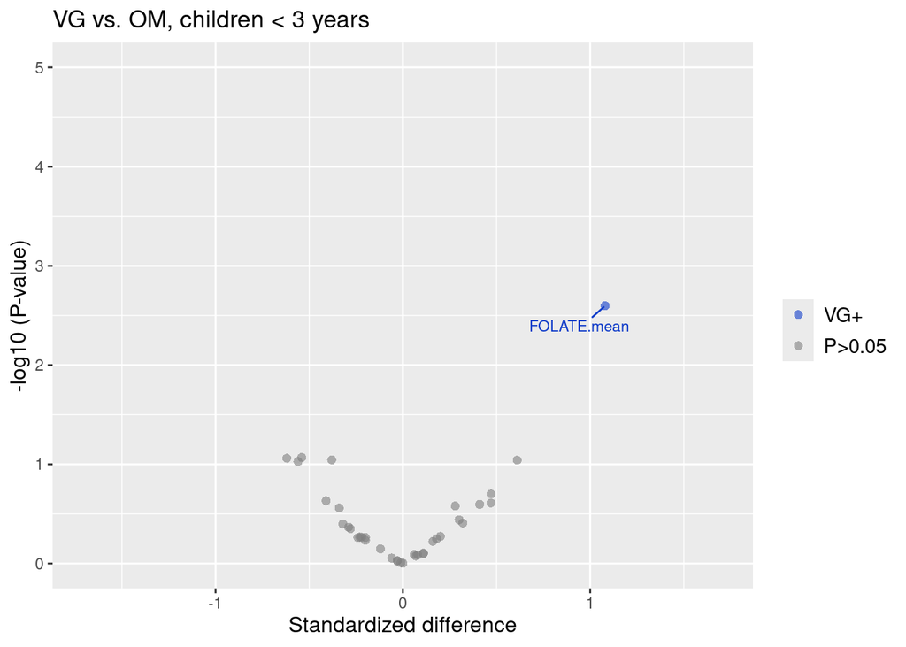

```r
plotac <- 'fig24'

path = paste0('gitignore/figures/',plotac, '.rds')

if(file.exists(path) == FALSE){
  assign(plotac, diet_child_young_Z %>%
           filter(estimand != 'log(OR)') %>%
           mutate(int = interaction(outcome, estimand)) %>%

           mutate(
             pv_adj = VG_OM_P_adj,
             pv_raw = VG_OM_P,
             b_coe = VG_OM_diff) %>%

           mutate(pv_raw = if_else(pv_raw < 1e-5, 1e-5, pv_raw)) %>%

           mutate(
             m_ylab = -log10(pv_raw),
             m_xlab = b_coe,
             rescat = if_else(
               pv_raw >= 0.05,
               'P>0.05',
               if_else(
                 b_coe > 0,
                 'VG+',
                 'OM+'))) %>%

           mutate(
             rescat = factor(rescat,
                             levels = c('OM+', 'VG+', 'P>0.05')),
             meta_labels = if_else(pv_raw < 0.05, int, '')) %>%

           ggplot(aes(x = b_coe,
                      y = m_ylab,
                      color = rescat,
                      alpha = rescat,
                      label = meta_labels)) +

           geom_point(size = 2, shape = 16, alpha = 0.6) +

           geom_text_repel(aes(
             x = m_xlab,
             y = m_ylab),
             show.legend = FALSE,
             alpha = 1,
             box.padding = 0.5,
             size = 3,
             seed = 17) +

           labs(x = 'Standardized difference', y = '-log10 (P-value)') +
           scale_color_manual(values = color_map, name = '') +
           ggtitle('VG vs. OM, children < 3 years') +
           theme(legend.text = element_text(size = 11),
                 axis.title = element_text(size = 12))+
           coord_cartesian(ylim = c(0, 5),
                           xlim = c(-1.7, 1.7))
         )

  saveRDS(get(plotac), file = path)
  get(plotac)

} else {assign(plotac, readRDS(path))
    get(plotac)}
```

### 4.2.3 VN vs VG

**Open code**

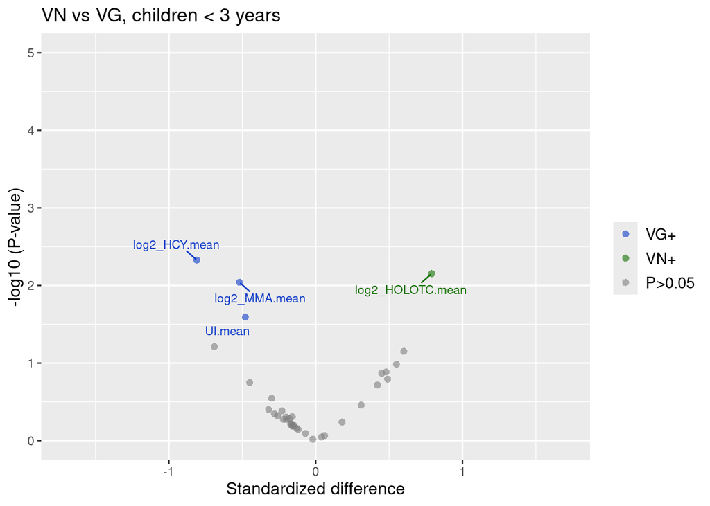

Figure 25. Vulcano plot showing standardized differences between VN and VG across clinical outcomes in children < 3 years, based on linear models.

```r
plotac <- 'fig25'

path = paste0('gitignore/figures/', plotac, '.rds')

if(file.exists(path) == FALSE){
  assign(plotac, diet_child_young_Z %>%
             filter(estimand != 'log(OR)') %>%
           mutate(int = interaction(outcome, estimand)) %>%

           mutate(
             pv_adj = VN_VG_P_adj,
             pv_raw = VN_VG_P,
             b_coe = VN_VG_diff) %>%

           mutate(pv_raw = if_else(pv_raw < 1e-5, 1e-5, pv_raw)) %>%

           mutate(
             m_ylab = -log10(pv_raw),
             m_xlab = b_coe,
             rescat = if_else(
               pv_raw >= 0.05,
               'P>0.05',
               if_else(
                 b_coe > 0,
                 'VN+',
                 'VG+'))) %>%


           mutate(
             rescat = factor(rescat,
                             levels=c('VG+',
                                      'VN+',
                                      'P>0.05')),
             meta_labels = if_else(pv_raw < 0.05, int, '')) %>%

           ggplot(aes(x = b_coe,
                      y = m_ylab,
                      color = rescat,
                      alpha = rescat,
                      label = meta_labels)) +

           geom_point(size = 2, shape = 16, alpha = 0.6) +

           geom_text_repel(aes(
             x = m_xlab,
             y = m_ylab),
             show.legend = FALSE,
             alpha = 1,
             box.padding = 0.5,
             size = 3,
             seed = 16) +

           labs(x = 'Standardized difference',
                y = '-log10 (P-value)') +

           scale_color_manual(values = color_map, name = '') +
           ggtitle('VN vs VG, children < 3 years') +

           theme(legend.text = element_text(size = 11),
                 axis.title = element_text(size = 12))+
           coord_cartesian(ylim = c(0, 5),
                           xlim = c(-1.7, 1.7))
         )

  saveRDS(get(plotac), file = path)
  get(plotac)

} else {assign(plotac, readRDS(path))
    get(plotac)}
```

## 4.3 Covariates importance

### 4.3.1 Table

**Open code**

```r
AIC_child_young <- read.xlsx("gitignore/data/AIC_child_young_mixeff.xlsx") %>%
  mutate(across(where(is.numeric), ~round(., 1)),
         outcome = clean_outcome_names(outcome)) %>%
  rename(
    SEX = aSEX,
    BREASTFEED = Breast_Feed,
    `OTHER COV` = other_cov,
    FAMILY = family,
    DIET = diet,
    AGE = log2_age
  ) %>%
  mutate(outcome = case_when(
    outcome == 'FOLAT' ~ 'FOLATE',
    outcome == 'VKFE' ~ 'TIBC',
    outcome == 'Cros' ~ 'CTX',
    outcome == 'log2_Cros' ~ 'log2_CTX',
    outcome == 'VIT_AKTB12' ~ 'HOLOTC',
    outcome == 'log2_VIT_AKTB12' ~ 'log2_HOLOTC',
    TRUE ~ outcome
  ))

kbl(AIC_child_young, caption =
      "Decrease of The Akaike information criterion (AIC) after addition of given outcome to linear models, children under 3 years. The change of AIC indicate out-of-sample predictive accuracy of the models and was bounded to -30 (large importance of a covariate) and 0 (no to negliable importance)") %>%
  kable_styling("striped",full_width = T) %>%
  column_spec(1, width_min = '1.5in')
```

Decrease of The Akaike information criterion (AIC) after addition of given outcome to linear models, children under 3 years. The change of AIC indicate out-of-sample predictive accuracy of the models and was bounded to -30 (large importance of a covariate) and 0 (no to negliable importance)

| outcome | estimand | AGE | SEX | BREASTFEED | OTHER COV | DIET | FAMILY |
| --- | --- | --- | --- | --- | --- | --- | --- |
| MASS_Perc | mean | NA | -0.9 | 0.3 | -19.4 | 2.1 | NA |
| HEIGHT_Perc | mean | NA | 25.4 | 2.6 | -12.2 | 2.1 | NA |
| BMI_PERC | mean | NA | -2.0 | 2.0 | -6.3 | 4.6 | NA |
| M_per_H_PERC | mean | NA | -1.0 | 2.0 | -6.6 | 4.4 | NA |
| GLY | mean | 2.4 | 2.6 | 4.8 | NA | 4.2 | NA |
| TC | mean | 2.0 | 2.2 | 5.3 | NA | 4.0 | NA |
| HDL | mean | 2.4 | -1.0 | 6.2 | NA | 4.5 | NA |
| LDL | mean | 1.4 | 2.2 | 2.5 | NA | 1.1 | NA |
| log2_TG | mean | 2.6 | -0.9 | 3.7 | NA | 1.5 | NA |
| Ca | mean | -8.3 | 2.5 | 6.1 | 2.5 | 4.9 | NA |
| P | mean | -10.0 | 2.2 | -0.3 | NA | 3.7 | NA |
| Mg | mean | 1.8 | -2.7 | 0.1 | 0.0 | 3.9 | NA |
| Se | mean | 2.5 | 0.8 | 3.3 | 2.0 | 4.2 | NA |
| Zn | mean | 2.5 | 2.5 | 7.0 | 1.7 | 3.1 | NA |
| FE | mean | -7.1 | 2.3 | 5.3 | -0.6 | 3.8 | NA |
| TIBC | mean | 2.3 | 1.4 | 2.6 | 2.6 | 2.9 | NA |
| log2_FERR | mean | 0.2 | 2.6 | -8.6 | -0.2 | 2.1 | NA |
| TRF | mean | 2.4 | 1.2 | 2.3 | 2.6 | 2.4 | NA |
| SATTRF | mean | -6.6 | 2.0 | 5.0 | -0.6 | 3.1 | NA |
| log2_TRFINDEX | mean | -0.9 | 1.5 | -4.4 | 0.4 | 4.7 | NA |
| log2_STRF | mean | -1.3 | 0.3 | -0.6 | 0.6 | 3.5 | NA |
| HGB | mean | 2.1 | -1.2 | 6.4 | NA | 2.5 | NA |
| MCV | mean | 1.3 | -1.3 | 2.1 | NA | -7.7 | NA |
| PTH | mean | 0.4 | 2.1 | 3.5 | NA | 3.7 | NA |
| log2_CTX | mean | -4.4 | 2.7 | -0.9 | 2.3 | 4.3 | NA |
| P1NP | mean | -42.3 | 2.7 | -6.4 | 5.2 | 3.7 | NA |
| UI | mean | 2.7 | 2.6 | 5.5 | NA | 4.5 | NA |
| UREA | mean | -5.0 | 2.6 | 3.8 | NA | -0.4 | NA |
| log2_CREA | mean | -1.8 | 2.6 | 6.8 | NA | 2.0 | NA |
| UA | mean | 1.7 | 2.5 | -0.2 | NA | 4.1 | NA |
| log2_HOLOTC | mean | 2.3 | -0.4 | 2.7 | 4.0 | -2.5 | NA |
| log2_HCY | mean | -0.7 | -3.2 | 0.4 | NA | -2.9 | NA |
| log2_MMA | mean | 0.9 | 2.5 | -1.2 | NA | -14.3 | NA |
| log2_VIT_D | mean | -2.8 | 2.6 | 3.1 | 1.7 | -1.3 | NA |
| FOLATE | mean | -5.2 | 2.6 | 5.7 | 2.7 | -6.3 | NA |
| log2_IGF1 | mean | -8.7 | 1.8 | -7.5 | NA | 4.5 | NA |

### 4.3.2 Heatmap

**Open code**

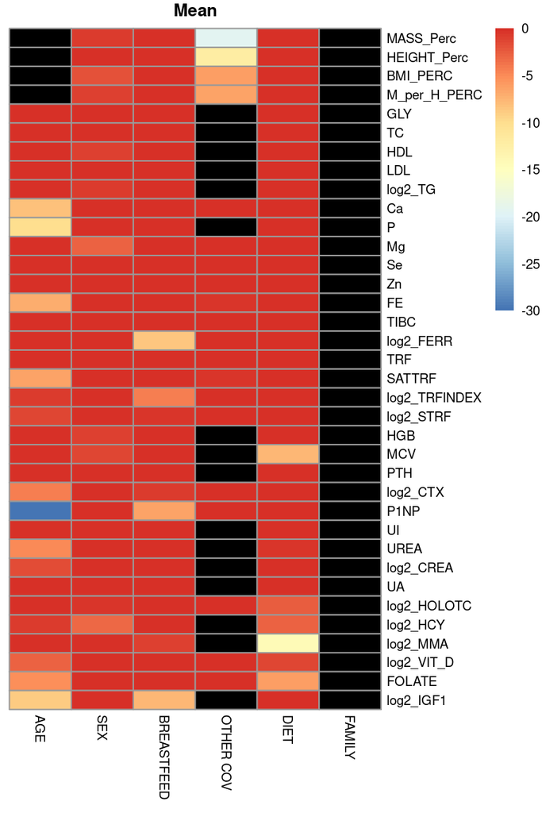

Heatmap showing the extend of decrase of the Akaike information criterion (AIC) after addition of given outcome to linear model, children < 3 years. The change of AIC indicate out-of-sample predictive accuracy of the models and was bounded to -30 (large importance of a covariate, blue) and 0 (no to negliable importance, red).

```r
heat_map(AIC_child_young, mixef = TRUE)
```

# 5 Old children

## 5.1 Diet effects

### 5.1.1 Unstandardized effects

**Open code**

```r
diet_child_old <- read.xlsx("gitignore/data/diet_child_old_mixeff.xlsx") %>%
  mutate(outcome = clean_outcome_names(outcome)) %>%
  mutate(outcome = case_when(
    outcome == 'FOLAT' ~ 'FOLATE',
    outcome == 'VKFE' ~ 'TIBC',
    outcome == 'Cros' ~ 'CTX',
    outcome == 'log2_Cros' ~ 'log2_CTX',
    outcome == 'VIT_AKTB12' ~ 'HOLOTC',
    outcome == 'log2_VIT_AKTB12' ~ 'log2_HOLOTC',
    TRUE ~ outcome
  ))

diet_child_old <- diet_child_old %>%
  mutate(across(.cols = c(VN_OM_diff, VG_OM_diff, VN_VG_diff), ~ round(.x, 2))) %>%
  filter(!is.na(VN_OM_diff))

kbl(diet_child_old, caption =
      "Differences between diet groups across outcomes in children > 3 years of age, based on quantile regression modelling") %>%
  kable_styling("striped",full_width = T) %>%
  add_header_above(c(" " = 2, "(A) VN vs OM" = 3,
                     "(B) VG vs OM" = 3, "(C) VN vs VG" =3)) %>%
  column_spec(1, width_min = '1.5in')
```

| outcome | estimand | (A) VN vs OM VN_OM_diff | (A) VN vs OM VN_OM_P | (A) VN vs OM VN_OM_P_adj | (B) VG vs OM VG_OM_diff | (B) VG vs OM VG_OM_P | (B) VG vs OM VG_OM_P_adj | (C) VN vs VG VN_VG_diff | (C) VN vs VG VN_VG_P | (C) VN vs VG VN_VG_P_adj |
| --- | --- | --- | --- | --- | --- | --- | --- | --- | --- | --- |
| MASS_Perc | mean | -15.03 | 0.12859 | 0.38370 | -14.10 | 0.19185 | 0.38370 | -0.94 | 0.92389 | 0.92389 |
| HEIGHT_Perc | mean | -13.80 | 0.17056 | 0.51169 | -7.84 | 0.47628 | 0.55115 | -5.95 | 0.55115 | 0.55115 |
| BMI_PERC | mean | -7.97 | 0.37476 | 0.74953 | -10.07 | 0.30524 | 0.74953 | 2.11 | 0.81287 | 0.81287 |
| M_per_H_PERC | mean | -7.82 | 0.39078 | 0.77028 | -10.47 | 0.29419 | 0.77028 | 2.64 | 0.77028 | 0.77028 |
| GLY | mean | 0.01 | 0.96640 | 0.96640 | -0.08 | 0.67586 | 0.96640 | 0.09 | 0.64025 | 0.96640 |
| TC | mean | -0.34 | 0.07483 | 0.22450 | -0.32 | 0.12889 | 0.25778 | -0.03 | 0.88966 | 0.88966 |
| HDL | mean | -0.03 | 0.76427 | 0.76427 | -0.14 | 0.21056 | 0.63168 | 0.10 | 0.33192 | 0.66383 |
| LDL | mean | -0.26 | 0.09330 | 0.27991 | -0.07 | 0.68417 | 0.68417 | -0.19 | 0.21367 | 0.42733 |
| log2_TG | mean | -0.08 | 0.72199 | 0.72199 | -0.41 | 0.10725 | 0.32176 | 0.32 | 0.16389 | 0.32777 |
| Ca | mean | 0.00 | 0.98575 | 0.98575 | 0.01 | 0.73966 | 0.98575 | -0.01 | 0.70515 | 0.98575 |
| P | mean | -0.07 | 0.27707 | 0.75097 | -0.06 | 0.37548 | 0.75097 | -0.01 | 0.89946 | 0.89946 |
| Mg | mean | 0.06 | 0.00433 | 0.01299 | 0.04 | 0.03474 | 0.06948 | 0.01 | 0.44638 | 0.44638 |
| Se | mean | -0.08 | 0.31821 | 0.73352 | -0.05 | 0.50156 | 0.73352 | -0.03 | 0.73352 | 0.73352 |
| Zn | mean | -0.52 | 0.52968 | 0.65366 | 0.36 | 0.65366 | 0.65366 | -0.87 | 0.29231 | 0.65366 |
| FE | mean | 1.32 | 0.60736 | 0.60736 | -2.06 | 0.42502 | 0.60736 | 3.38 | 0.18106 | 0.54317 |
| TIBC | mean | -3.15 | 0.29961 | 0.71159 | -1.13 | 0.71159 | 0.71159 | -2.02 | 0.50040 | 0.71159 |
| log2_FERR | mean | -0.47 | 0.04270 | 0.12438 | -0.04 | 0.85201 | 0.85201 | -0.42 | 0.06219 | 0.12438 |
| TRF | mean | -0.13 | 0.26718 | 0.60632 | -0.06 | 0.60632 | 0.60632 | -0.07 | 0.54968 | 0.60632 |
| SATTRF | mean | 2.17 | 0.58813 | 0.75075 | -1.35 | 0.75075 | 0.75075 | 3.52 | 0.37644 | 0.75075 |
| log2_TRFINDEX | mean | 0.20 | 0.08841 | 0.26522 | 0.08 | 0.50359 | 0.50359 | 0.12 | 0.29650 | 0.50359 |
| log2_STRF | mean | 0.05 | 0.47595 | 0.58761 | 0.08 | 0.21622 | 0.58761 | -0.03 | 0.58761 | 0.58761 |
| HGB | mean | -1.66 | 0.58236 | 0.58236 | 3.01 | 0.35572 | 0.58236 | -4.67 | 0.11940 | 0.35820 |
| MCV | mean | 2.66 | 0.00609 | 0.01218 | -1.20 | 0.25163 | 0.25163 | 3.86 | 0.00006 | 0.00019 |
| PTH | mean | 0.17 | 0.63017 | 0.77984 | -0.11 | 0.77984 | 0.77984 | 0.28 | 0.42989 | 0.77984 |
| log2_CTX | mean | 0.01 | 0.96872 | 0.96872 | 0.07 | 0.62379 | 0.96872 | -0.06 | 0.60852 | 0.96872 |
| P1NP | mean | 77.78 | 0.08050 | 0.24149 | 36.95 | 0.44671 | 0.44671 | 40.83 | 0.33391 | 0.44671 |
| UI | mean | -82.83 | 0.00569 | 0.01706 | -56.92 | 0.07462 | 0.14923 | -25.91 | 0.38015 | 0.38015 |
| UREA | mean | -0.59 | 0.08096 | 0.16192 | 0.12 | 0.74659 | 0.74659 | -0.71 | 0.03568 | 0.10703 |
| log2_CREA | mean | -0.04 | 0.60222 | 0.90605 | -0.03 | 0.68874 | 0.90605 | -0.01 | 0.90605 | 0.90605 |
| UA | mean | 0.68 | 0.95700 | 0.95700 | 7.52 | 0.55183 | 0.95700 | -6.85 | 0.58207 | 0.95700 |
| log2_HOLOTC | mean | 0.06 | 0.84068 | 0.84068 | -0.34 | 0.23599 | 0.47199 | 0.39 | 0.05339 | 0.16016 |
| log2_HCY | mean | -0.06 | 0.53553 | 0.79007 | -0.03 | 0.79007 | 0.79007 | -0.03 | 0.75959 | 0.79007 |
| log2_MMA | mean | -0.34 | 0.06506 | 0.19517 | -0.12 | 0.53149 | 0.53149 | -0.21 | 0.24044 | 0.48088 |
| log2_VIT_D | mean | 0.27 | 0.04532 | 0.13597 | 0.24 | 0.10220 | 0.20440 | 0.03 | 0.83799 | 0.83799 |
| FOLATE | mean | 4.62 | 0.00313 | 0.00940 | 4.45 | 0.00872 | 0.01744 | 0.17 | 0.91253 | 0.91253 |
| log2_IGF1 | mean | -0.26 | 0.16945 | 0.50834 | -0.06 | 0.78190 | 0.78190 | -0.20 | 0.28448 | 0.56896 |

### 5.1.2 Standardized effects by 1SD

**Open code**

```r
ids <- 11:45
inde <- min(ids)-1
ids <- ids-inde

sds <- vector("double", max(ids))

for(i in seq_along(ids)){
  sds[i] <- ifelse(grepl("log2", diet_child_old[(i),1]),
                   sd(log2(dat_child_old[,(i+inde)]), na.rm=TRUE),
                   sd(dat_child_old[,(i+inde)], na.rm=TRUE))
}

sds[length(ids) +1] <- 1

diet_child_old_Z <- diet_child_old %>%
  mutate(SD = sds) %>%
  mutate(VN_OM_diff = VN_OM_diff/SD,
         VG_OM_diff = VG_OM_diff/SD,
         VN_VG_diff = VN_VG_diff/SD) %>%
  select(-SD) %>%
  mutate(across(.cols = c(VN_OM_diff, VG_OM_diff, VN_VG_diff), ~ round(.x, 2)))

kbl(diet_child_old_Z, caption =
      "Standardized differences between diet groups across outcomes in children > 3 years of age, based on quantile regression modelling") %>%
  kable_styling("striped",full_width = T) %>%
  add_header_above(c(" " = 2, "(A) VN vs OM" = 3,
                     "(B) VG vs OM" = 3, "(C) VN vs VG" =3)) %>%
  column_spec(1, width_min = '1.5in')
```

| outcome | estimand | (A) VN vs OM VN_OM_diff | (A) VN vs OM VN_OM_P | (A) VN vs OM VN_OM_P_adj | (B) VG vs OM VG_OM_diff | (B) VG vs OM VG_OM_P | (B) VG vs OM VG_OM_P_adj | (C) VN vs VG VN_VG_diff | (C) VN vs VG VN_VG_P | (C) VN vs VG VN_VG_P_adj |
| --- | --- | --- | --- | --- | --- | --- | --- | --- | --- | --- |
| MASS_Perc | mean | -0.54 | 0.12859 | 0.38370 | -0.51 | 0.19185 | 0.38370 | -0.03 | 0.92389 | 0.92389 |
| HEIGHT_Perc | mean | -0.50 | 0.17056 | 0.51169 | -0.28 | 0.47628 | 0.55115 | -0.22 | 0.55115 | 0.55115 |
| BMI_PERC | mean | -0.34 | 0.37476 | 0.74953 | -0.43 | 0.30524 | 0.74953 | 0.09 | 0.81287 | 0.81287 |
| M_per_H_PERC | mean | -0.33 | 0.39078 | 0.77028 | -0.44 | 0.29419 | 0.77028 | 0.11 | 0.77028 | 0.77028 |
| GLY | mean | 0.01 | 0.96640 | 0.96640 | -0.11 | 0.67586 | 0.96640 | 0.13 | 0.64025 | 0.96640 |
| TC | mean | -0.54 | 0.07483 | 0.22450 | -0.51 | 0.12889 | 0.25778 | -0.05 | 0.88966 | 0.88966 |
| HDL | mean | -0.09 | 0.76427 | 0.76427 | -0.42 | 0.21056 | 0.63168 | 0.30 | 0.33192 | 0.66383 |
| LDL | mean | -0.55 | 0.09330 | 0.27991 | -0.15 | 0.68417 | 0.68417 | -0.40 | 0.21367 | 0.42733 |
| log2_TG | mean | -0.13 | 0.72199 | 0.72199 | -0.66 | 0.10725 | 0.32176 | 0.51 | 0.16389 | 0.32777 |
| Ca | mean | 0.00 | 0.98575 | 0.98575 | 0.11 | 0.73966 | 0.98575 | -0.11 | 0.70515 | 0.98575 |
| P | mean | -0.43 | 0.27707 | 0.75097 | -0.37 | 0.37548 | 0.75097 | -0.06 | 0.89946 | 0.89946 |
| Mg | mean | 1.01 | 0.00433 | 0.01299 | 0.67 | 0.03474 | 0.06948 | 0.17 | 0.44638 | 0.44638 |
| Se | mean | -0.26 | 0.31821 | 0.73352 | -0.16 | 0.50156 | 0.73352 | -0.10 | 0.73352 | 0.73352 |
| Zn | mean | -0.19 | 0.52968 | 0.65366 | 0.13 | 0.65366 | 0.65366 | -0.32 | 0.29231 | 0.65366 |
| FE | mean | 0.18 | 0.60736 | 0.60736 | -0.27 | 0.42502 | 0.60736 | 0.45 | 0.18106 | 0.54317 |
| TIBC | mean | -0.33 | 0.29961 | 0.71159 | -0.12 | 0.71159 | 0.71159 | -0.21 | 0.50040 | 0.71159 |
| log2_FERR | mean | -0.71 | 0.04270 | 0.12438 | -0.06 | 0.85201 | 0.85201 | -0.64 | 0.06219 | 0.12438 |
| TRF | mean | -0.35 | 0.26718 | 0.60632 | -0.16 | 0.60632 | 0.60632 | -0.19 | 0.54968 | 0.60632 |
| SATTRF | mean | 0.21 | 0.58813 | 0.75075 | -0.13 | 0.75075 | 0.75075 | 0.34 | 0.37644 | 0.75075 |
| log2_TRFINDEX | mean | 0.59 | 0.08841 | 0.26522 | 0.24 | 0.50359 | 0.50359 | 0.36 | 0.29650 | 0.50359 |
| log2_STRF | mean | 0.26 | 0.47595 | 0.58761 | 0.41 | 0.21622 | 0.58761 | -0.15 | 0.58761 | 0.58761 |
| HGB | mean | -0.20 | 0.58236 | 0.58236 | 0.37 | 0.35572 | 0.58236 | -0.57 | 0.11940 | 0.35820 |
| MCV | mean | 0.84 | 0.00609 | 0.01218 | -0.38 | 0.25163 | 0.25163 | 1.22 | 0.00006 | 0.00019 |
| PTH | mean | 0.18 | 0.63017 | 0.77984 | -0.12 | 0.77984 | 0.77984 | 0.30 | 0.42989 | 0.77984 |
| log2_CTX | mean | 0.02 | 0.96872 | 0.96872 | 0.17 | 0.62379 | 0.96872 | -0.15 | 0.60852 | 0.96872 |
| P1NP | mean | 0.65 | 0.08050 | 0.24149 | 0.31 | 0.44671 | 0.44671 | 0.34 | 0.33391 | 0.44671 |
| UI | mean | -0.59 | 0.00569 | 0.01706 | -0.40 | 0.07462 | 0.14923 | -0.18 | 0.38015 | 0.38015 |
| UREA | mean | -0.59 | 0.08096 | 0.16192 | 0.12 | 0.74659 | 0.74659 | -0.71 | 0.03568 | 0.10703 |
| log2_CREA | mean | -0.13 | 0.60222 | 0.90605 | -0.10 | 0.68874 | 0.90605 | -0.03 | 0.90605 | 0.90605 |
| UA | mean | 0.02 | 0.95700 | 0.95700 | 0.19 | 0.55183 | 0.95700 | -0.17 | 0.58207 | 0.95700 |
| log2_HOLOTC | mean | 0.09 | 0.84068 | 0.84068 | -0.50 | 0.23599 | 0.47199 | 0.57 | 0.05339 | 0.16016 |
| log2_HCY | mean | -0.18 | 0.53553 | 0.79007 | -0.09 | 0.79007 | 0.79007 | -0.09 | 0.75959 | 0.79007 |
| log2_MMA | mean | -0.56 | 0.06506 | 0.19517 | -0.20 | 0.53149 | 0.53149 | -0.34 | 0.24044 | 0.48088 |
| log2_VIT_D | mean | 0.57 | 0.04532 | 0.13597 | 0.51 | 0.10220 | 0.20440 | 0.06 | 0.83799 | 0.83799 |
| FOLATE | mean | 0.99 | 0.00313 | 0.00940 | 0.95 | 0.00872 | 0.01744 | 0.04 | 0.91253 | 0.91253 |
| log2_IGF1 | mean | -0.26 | 0.16945 | 0.50834 | -0.06 | 0.78190 | 0.78190 | -0.20 | 0.28448 | 0.56896 |

## 5.2 Vulcano plot

### 5.2.1 VN vs OM

**Open code**

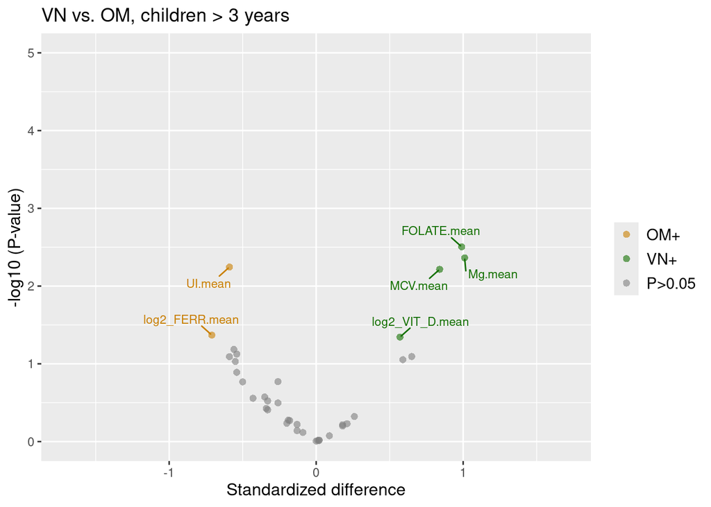

```r
plotac <- 'fig27'

path = paste0('gitignore/figures/',plotac, '.rds')

if(file.exists(path) == FALSE){
  assign(plotac, diet_child_old_Z %>%
           filter(estimand != 'log(OR)') %>%
           mutate(int = interaction(outcome, estimand)) %>%

           mutate(
             pv_adj = VN_OM_P_adj,
             pv_raw = VN_OM_P,
             b_coe = VN_OM_diff) %>%

           mutate(pv_raw = if_else(pv_raw < 1e-5, 1e-5, pv_raw)) %>%

           mutate(
             m_ylab = -log10(pv_raw),
             m_xlab = b_coe,
             rescat = if_else(
               pv_raw >= 0.05,
               'P>0.05',
               if_else(
                 b_coe > 0,
                 'VN+',
                 'OM+'))) %>%

           mutate(
             rescat = factor(rescat,
                             levels = c('OM+', 'VN+', 'P>0.05')),
             meta_labels = if_else(pv_raw < 0.05, int, '')) %>%

           ggplot(aes(x = b_coe,
                      y = m_ylab,
                      color = rescat,
                      alpha = rescat,
                      label = meta_labels)) +

           geom_point(size = 2, shape = 16, alpha = 0.6) +

           geom_text_repel(aes(
             x = m_xlab,
             y = m_ylab),
             show.legend = FALSE,
             alpha = 1,
             box.padding = 0.5,
             size = 3,
             seed = 17) +

           labs(x = 'Standardized difference', y = '-log10 (P-value)') +
           scale_color_manual(values = color_map, name = '') +
           ggtitle('VN vs. OM, children > 3 years') +
           theme(legend.text = element_text(size = 11),
                 axis.title = element_text(size = 12))+
           coord_cartesian(ylim = c(0, 5),
                           xlim = c(-1.7, 1.7))
         )

  saveRDS(get(plotac), file = path)
  get(plotac)

} else {assign(plotac, readRDS(path))
    get(plotac)}
```

### 5.2.2 VG vs OM

**Open code**

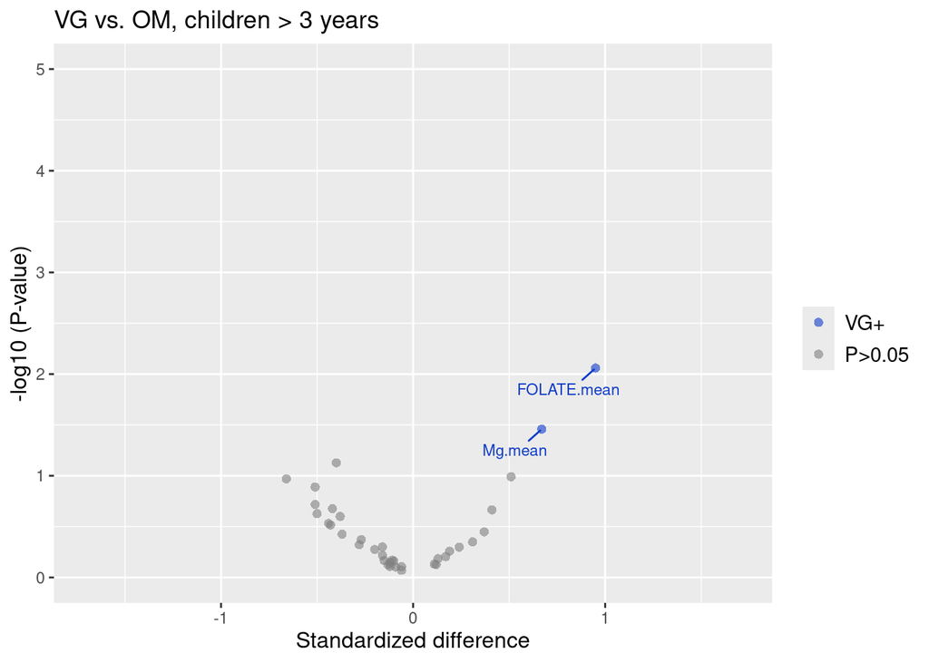

```r
plotac <- 'fig28'

path = paste0('gitignore/figures/',plotac, '.rds')

if(file.exists(path) == FALSE){
  assign(plotac, diet_child_old_Z %>%
           filter(estimand != 'log(OR)') %>%
           mutate(int = interaction(outcome, estimand)) %>%

           mutate(
             pv_adj = VG_OM_P_adj,
             pv_raw = VG_OM_P,
             b_coe = VG_OM_diff) %>%

           mutate(pv_raw = if_else(pv_raw < 1e-5, 1e-5, pv_raw)) %>%

           mutate(
             m_ylab = -log10(pv_raw),
             m_xlab = b_coe,
             rescat = if_else(
               pv_raw >= 0.05,
               'P>0.05',
               if_else(
                 b_coe > 0,
                 'VG+',
                 'OM+'))) %>%

           mutate(
             rescat = factor(rescat,
                             levels = c('OM+', 'VG+', 'P>0.05')),
             meta_labels = if_else(pv_raw < 0.05, int, '')) %>%

           ggplot(aes(x = b_coe,
                      y = m_ylab,
                      color = rescat,
                      alpha = rescat,
                      label = meta_labels)) +

           geom_point(size = 2, shape = 16, alpha = 0.6) +
           geom_text_repel(aes(
             x = m_xlab,
             y = m_ylab),
             show.legend = FALSE,
             alpha=1,
             box.padding = 0.5,
             size = 3,
             seed = 17) +

           labs(x = 'Standardized difference', y = '-log10 (P-value)') +
           scale_color_manual(values = color_map, name = '') +
           ggtitle('VG vs. OM, children > 3 years') +
           theme(legend.text = element_text(size = 11),
                 axis.title = element_text(size = 12))+
           coord_cartesian(ylim = c(0, 5),
                           xlim = c(-1.7, 1.7))
         )

  saveRDS(get(plotac), file = path)
  get(plotac)

} else {assign(plotac, readRDS(path))
    get(plotac)}
```

### 5.2.3 VN vs VG

**Open code**

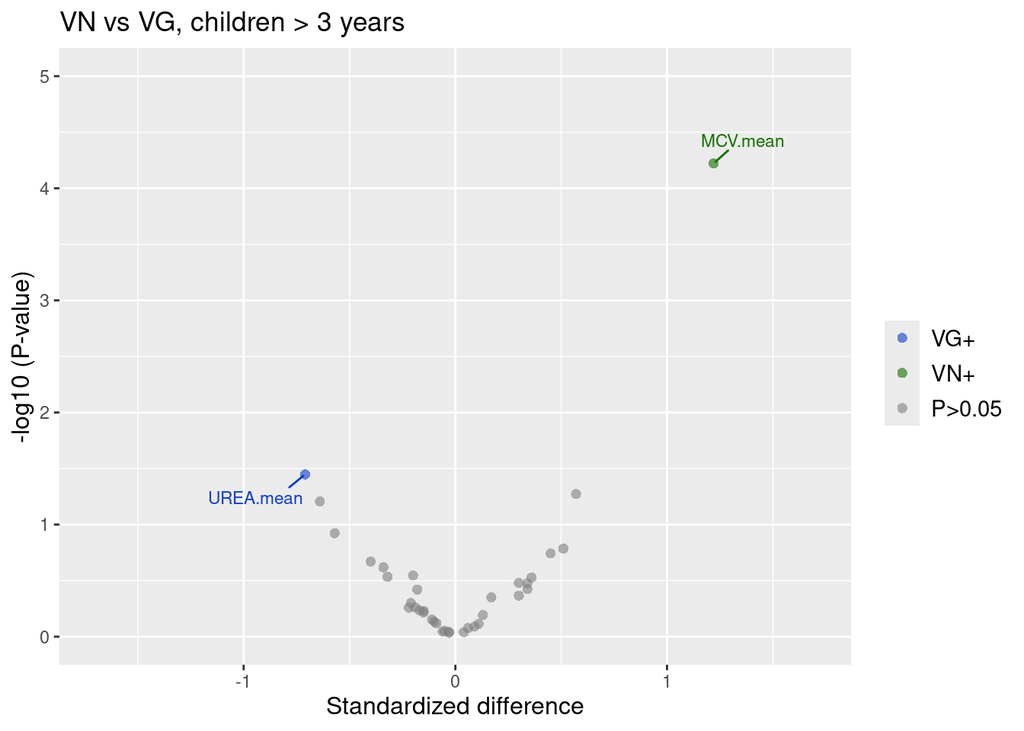

Figure 29. Vulcano plot showing standardized differences between VG and VN across clinical outcomes in children <>3 years.

```r
plotac <- 'fig29'

path = paste0('gitignore/figures/', plotac, '.rds')

if(file.exists(path) == FALSE){
  assign(plotac, diet_child_old_Z %>%
             filter(estimand != 'log(OR)') %>%
           mutate(int = interaction(outcome, estimand)) %>%

           mutate(
             pv_adj = VN_VG_P_adj,
             pv_raw = VN_VG_P,
             b_coe = VN_VG_diff) %>%

           mutate(pv_raw = if_else(pv_raw < 1e-5, 1e-5, pv_raw)) %>%

           mutate(
             m_ylab = -log10(pv_raw),
             m_xlab = b_coe,
             rescat = if_else(
               pv_raw >= 0.05,
               'P>0.05',
               if_else(
                 b_coe > 0,
                 'VN+',
                 'VG+'))) %>%

           mutate(
             rescat = factor(rescat,
                             levels=c('VG+',
                                      'VN+',
                                      'P>0.05')),
             meta_labels = if_else(pv_raw < 0.05, int, '')) %>%

           ggplot(aes(x = b_coe,
                      y = m_ylab,
                      color = rescat,
                      alpha = rescat,
                      label = meta_labels)) +

           geom_point(size = 2, shape = 16, alpha = 0.6) +

           geom_text_repel(aes(
             x = m_xlab,
             y = m_ylab),
             show.legend = FALSE,
             alpha = 1,
             box.padding = 0.5,
             size = 3,
             seed = 16) +

           labs(x = 'Standardized difference',
                y = '-log10 (P-value)') +

           scale_color_manual(values = color_map, name = '') +
           ggtitle('VN vs VG, children > 3 years') +

           theme(legend.text = element_text(size = 11),
                 axis.title = element_text(size = 12))+
           coord_cartesian(ylim = c(0, 5),
                           xlim = c(-1.7, 1.7))
         )

  saveRDS(get(plotac), file = path)
  get(plotac)

} else {assign(plotac, readRDS(path))
    get(plotac)}
```